# COVID-19 excess

William Msemburi (WHO)

10 May 2021

# 1 BACKGROUND

Emerging only at the end of 2019 and declared by WHO as a global pandemic in March of 2020, COVID-19 has wrought an unprecedented devastation on global population health. By 1 January 2021 83.2 million confirmed cases and 1.8 million deaths had been reported to WHO. And as of May 10 2021, there are 157.3 million confirmed COVID-19 cases and 3.3 million deaths that have been reported to WHO (an additional 74.1 million cases and 1.5 million deaths in 2021 so far).

[interactive chart not shown]

However, the reported COVID-19 burden has given an incomplete picture of the true impact of covid. There are a number of reasons for this:

- there have been significant variations in testing access across countries,
- some countries have better diagnostic capacity than others,
- and over the course of the pandemic, there have been differences in how COVID-19 deaths have been defined and certified.

As a result of this, in many cases, deaths caused by COVID-19 have been incorrectly attributed to other causes.

## 1.1 Excess mortality attributable to COVID-19

The excess mortality measure is crucial for accurately quantifying impact. The WHO [defines](https://www.who.int/hac/about/definitions/en/) excess mortality as “*the mortality above what would be expected based on the non-crisis mortality rate in the population of interest*”. Excess mortality is thus the mortality that is attributable to the crisis conditions.

To consider the impact of COVID-19, the mortality rate for year 2020, week $t$ and age $x$, can be represented by
$$m^o_{x, t}$$
and is assumed to be a result of the direct effects of COVID-19 (deaths attributable to it) and the indirect knock-on effects on health systems and society. These indirect effects impact the number of deaths due to other natural as well as external causes. The hypothetical or “counterfactual” no-COVID-19 scenario has expected mortality rate
$$m^e_{x, t}$$
which is estimated as the average of the most recent death rates (prior to the pandemic) or the forecast of historical rates to 2020. Excess mortality, represented by $\mu_{x, t}$, can thus be defined as the difference:
$$\mu_{x, t} = m^o_{x, t} - m^e_{x, t}$$
evaluated in rate-space to account for population changes and estimated as an absolute rate difference or percentage change. This gives a more comprehensive picture of how a location has been affected by the disease.

[interactive chart not shown]

**There is a data gap to overcome**. Routine mortality data is usually received on an annual basis after the year of death or following an even longer lag. Civil registration and vital statistics (CRVS) systems differ across countries with varying timeline and quality control measures for compiling unit record cause-of-death numbers into aggregates indentified by cause, age, sex, place and period of death. In addition, differential reporting capacity and variable data quality across countries has resulted in many nations lacking the systems to provide good quality routine data in the past. Correspondingly, they also lack the capacity and data required to monitor all-cause mortality during this unprecedented pandemic. This results in a number of countries being unable to contribute to a centralized systematic mortality surveillance that would be needed to measure global, regional and country level excess mortality by the WHO.

[interactive chart not shown]

**To track excess mortality globally** requires the development of tools and strategies for capturing all-cause mortality that account for the current state of irregular mortality tracking as well as imperfect country capacity. This will be achieved using three complementary exercises:

- *Identifying countries that have timely and complete all-cause numbers* for which the counterfactual and the observed mortality, and thus the excess, can be determined directly. This includes identifying non-conventional data sources that may provide intermediate estimates of mortality within the CRVS pipeline;
- *Rapid upscale of the rate at which all-cause mortality is recorded* through short term surveillance systems that are built to track all the mortality experienced during this pandemic in real time and to supplement routine systems but are not comprehensive for cause or other granular detail.
- *Predicting the expected excess mortality for places with insufficient data to obtain estimates empirically*. This by using statistical models that leverage the estimates from the countries where mortality is known and using them to inform plausible estimates for the countries where it is not, considering country age-, sex-, cause- and income-profiles. We note that such a solution is sub-optimal and vulnerable to the bias implicit in making inference about an unknown quantity based on incomplete information. The optimal long-term goal would be to strengthen country surveillance and to build efficient and reliable death registration systems that are at maximal coverage for all countries. In the absence of these, however, this allows for the tracking of excess mortality of more countries that can be used to generate reasonable regional and global estimates.

Over the next few sections, more detail is provided on the preliminary statistical modeling exercises.

# 2 DATA INPUT

```r
#####################################################################################################################################
# House keeping
rm(list = ls(all = TRUE))
setwd(dirname(rstudioapi::getActiveDocumentContext()$path))

pacman::p_load(data.table, lubridate, tidyr, dplyr, countrycode)

#####################################################################################################################################
# Additional files for analysis
#####################################################################################################################################

# 1) Codes for mapping iso2 to iso3 for WHO public data
# 2) Total population numbers by country for 2020 (WPP2019 for 194 Member States)
# 3) GHE data by broad cause group, age, sex and year 2000 to 2019 (183/194 member states)
# 4) GBD data by broad cause group, age, sex and year 2000 to 2019 (11/194 member states)

ccodes      <- fread("https://www.dropbox.com/s/hoefrsvbk3lz389/ccodes.csv?dl=1")
population  <- fread("https://www.dropbox.com/s/nfmbu67o03kw8o4/population.csv?dl=1")

gheg3       <- fread("https://www.dropbox.com/s/cigt1ahro12qers/group3causes_ghe_183.csv?dl=1") %>%
  mutate(sex       = factor(sex, labels = c("Male", "Female")),
         causename = case_when(causename == "All Causes" ~ "All",
                               causename == "Communicable, maternal, perinatal and nutritional conditions" ~ "Communicable",
                               causename == "Noncommunicable diseases" ~ "Noncommunicable",
                               TRUE ~ as.character(causename))) %>%
  select(iso3, year, age, sex, causename, dths)

gbdg3       <- fread("https://www.dropbox.com/s/5hpa957mbzk9mrs/group3causes_gbd_11.csv?dl=1") %>%
  rename(agel = age, causename = cause, dths = val) %>%
  left_join(data.table(iso3 = c("AND","COK","DMA","MHL","MCO","NRU","NIU","PLW","KNA","SMR","TUV"),
             location = c("Andorra", "Cook Islands", "Dominica", "Marshall Islands","Monaco",
                          "Nauru", "Niue", "Palau", "Saint Kitts and Nevis", "San Marino", "Tuvalu")), by = "location") %>%
  left_join(data.table(age = seq(0,85,5), agel = c("Under 5", paste(seq(5,80,5),"to",seq(5,80,5)+4),"85 plus")), by="agel") %>%
  mutate(sex       = factor(sex, levels = c("Male", "Female")),
         causename = case_when(causename == "All causes" ~ "All",
                               causename == "Communicable, maternal, neonatal, and nutritional diseases" ~ "Communicable",
                               causename == "Non-communicable diseases" ~ "Noncommunicable",
                               TRUE ~ as.character(causename))) %>%
  select(iso3, year, age, sex, causename, dths)

# Combine the GHE and GBD based broad cause numbers

group3_194   <- rbind(gheg3, gbdg3) %>%
  group_by(iso3, year, causename) %>% summarise(dths = sum(dths), .groups = "drop") %>% ungroup() %>%
  spread(causename, dths) %>% arrange(iso3, year) %>% right_join(population, by = c("iso3","year"))

# Use the 2019 rates for NCDs, Communicable diseases and injuries as potential covariates

covariate.ghe<- group3_194 %>%
  filter(year == 2019)  %>% select(-c(year, All)) %>%
  gather(cause, val, -iso3, -pop) %>% mutate(val=1e5*val/pop) %>% spread(cause, val) %>% mutate(pop=NULL)

#####################################################################################################################################
# Time-series random walk order 2 for forecast of expected deaths in 2020
#####################################################################################################################################

# Function to forecast the GHE all cause deaths for a single year

expected.ghe <- function(){
  set.seed(12345)
  iso.list   <- sort(unique(group3_194$iso3)) # vector of iso3 to loop through;
  ex.list    <- list()                        # empty list to store expected values in;

for (i in 1:194){
  print(paste0(round(100*i/194,1), "%"))

  group3.subset <- group3_194 %>% filter(iso3 == iso.list[i]) %>%
    arrange(year) %>% select(iso3, year, All) %>% mutate(lall = log(All))

    fit         <- inla(lall ~ f(year, model = "rw2"), data = group3.subset, control.predictor= list(compute=TRUE))
    fit.out     <- data.table(expected = exp(fit$summary.fitted.values$mean),
                              fit.l    = exp(fit$summary.fitted.values$"0.025quant"),
                              fit.u    = exp(fit$summary.fitted.values$"0.975quant"))

    ex.list[[i]]<- cbind(group3.subset %>% mutate(lall = NULL), fit.out)
}
rbindlist(ex.list)
}

# takes a few min to run the function
# expected.out <- expected.ghe()
# fwrite(expected.out, file = "Data/expected.out.csv", row.names = F)

# loading the saved output from run

expected.out <- fread("https://www.dropbox.com/s/yjr1s99s2cmdpdb/expected.out.csv?dl=1")

ghe.expected <- expected.out %>%
  filter(year == 2020) %>% select(iso3, expected) %>%
  mutate(expected = round(0.25*expected), observed = NA)

ghe.expected <- rbind(ghe.expected %>% mutate(quarter = "q1"),
                      ghe.expected %>% mutate(quarter = "q2"),
                      ghe.expected %>% mutate(quarter = "q3"),
                      ghe.expected %>% mutate(quarter = "q4")) %>% arrange(iso3, quarter)


#####################################################################################################################################
# WHO COVID case and death data by date and country
#####################################################################################################################################

# Read in the WHO data and clean up some of the names

who_df      <- fread("https://covid19.who.int/WHO-COVID-19-global-data.csv") %>%
  mutate(Country_code = ifelse(Country == "Namibia", "NA", Country_code)) %>%
  left_join(ccodes, by = "Country_code") %>%
  mutate(Country = case_when(Country == "CuraÃ§ao" ~ "Curacao",
                             Country == "Saint BarthÃ©lemy" ~ "Saint Barthelemy",
                             Country == "RÃ©union" ~ "Reunion",
                             Country == "Kosovo[1]" ~ "Kosovo",
                             Country %in% c("Bonaire","Saba","Sint Eustatius") ~ "Bonaire, Sint Eustatius and Saba",
                             TRUE ~ as.character(Country)),
         iso3    = case_when(Country == "Kosovo" ~ "XKX",
                             Country == "Saint Martin"~ "MAF",
                             Country == "Sint Maarten"~ "SXM",
                             Country == "Bonaire, Sint Eustatius and Saba" ~ "BES",
                             Country == "Curacao" ~ "CUW",
                             Country == "Saint Barthelemy" ~ "BLM",
                             Country == "South Sudan" ~ "SSD",
                             Country == "Namibia" ~ "NAM",
                             TRUE ~ as.character(iso3)),
         date    = as.Date(Date_reported,"%y-%m-%d")) %>%
  rename(cov_cases  = Cumulative_cases, cov_deaths = Cumulative_deaths)
```

```r
# Subset to the 194 member states and aggregate cases and deaths by quarter of death

who_2020_194 <- who_df %>%
  filter(date =="2020-04-01" | date =="2020-07-01"| date =="2020-10-01" | date =="2021-01-01") %>%
  mutate(period = case_when(date == "2020-04-01" ~ "p1",
                            date == "2020-07-01" ~ "p2",
                            date == "2020-10-01" ~ "p3",
                            date == "2021-01-01" ~ "p4")) %>%
  select(Country, iso3, WHO_region, period, cov_cases, cov_deaths) %>%
  gather(source, val, -Country, -iso3, -WHO_region, -period) %>%
  group_by(Country, iso3, WHO_region, period, source) %>%
  summarise(val = sum(val, na.rm = T), .groups = "drop") %>% ungroup() %>%
  spread(period, val) %>%
  mutate(q1 = p1, q2 = p2 - p1, q3 = p3 - p2, q4 = p4 - p3) %>%
  select(-c(p1, p2, p3, p4)) %>%
  gather(quarter, val, -Country, -iso3, -WHO_region, -source) %>%
  spread(source, val) %>%
  right_join(population %>% filter(year == 2020), by = "iso3") %>%
  mutate(WHO_region = factor(WHO_region,
             levels = c("AFRO","AMRO","EMRO","EURO","SEARO","WPRO"))) %>%
  arrange(iso3, quarter) %>%
  group_by(iso3) %>%
  mutate(cc_all = 1e5*sum(cov_cases)/pop, cd_all = 1e5*sum(cov_deaths)/pop) %>% ungroup()


#####################################################################################################################################
# SDI data from GBD and Income group from World Bank
#####################################################################################################################################

# SDI, filter for country locations (leave out region or subnational; & Georgia in the USA)

sdi.loc <- fread("https://www.dropbox.com/s/vhajcoyzw08wb8l/sdi.country.csv?dl=1")
temp    <- tempfile(fileext = ".xlsx")
dataURL <- "http://ghdx.healthdata.org/sites/default/files/record-attached-files/IHME_GBD_2019_SDI_1990_2019_Y2020M10D15.XLSX"
download.file(dataURL, destfile=temp, mode='wb')

sdi.gbd <- readxl::read_excel(temp, skip = 1)[-c(105), ] %>%
  filter(Location %in% sdi.loc$Location & Location != "Virgin Islands" ) %>%
  mutate(iso3 = countrycode(Location, "country.name", "iso3c")) %>%
  gather(year, sdi, -Location, -iso3) %>%
  mutate(sdi=as.numeric(gsub( "·", ".",sdi)), year = as.numeric(year), Location = NULL) %>%
  filter(year == 2019 & iso3 %in% unique(population$iso3)) %>%
  select(-c(year))

# Income group from World Bank, assume Cook Islands and Niue are upper middle income like Tonga and Tuvalu

temp     <- tempfile(fileext = ".xls")
dataURL  <- "http://databank.worldbank.org/data/download/site-content/CLASS.xls"
download.file(dataURL, destfile=temp, mode='wb')

wbincome <- readxl::read_excel(temp, skip = 4) %>%
  filter(Code != "x") %>%
  select(Code, `Income group`) %>%
  rename(iso3 = Code, group = "Income group") %>%
  filter(iso3 %in% unique(population$iso3))

wb_oth   <- wbincome  %>%
  filter(iso3 %in% c("TON","TUV")) %>% mutate(iso3 = c("COK", "NIU"))

wbincome <- wbincome %>% rbind(wb_oth)


#####################################################################################################################################
# Observed compiled data from Karlinsky et al and multiple sources
#####################################################################################################################################

# The baseline are forcasted by time using the linear regression function
# Will compare the aggregate for Ariels forecasts to the aggregate GHE forecasts

baseline_data <- fread("https://raw.github.com/dkobak/excess-mortality/main/baselines.csv") %>%
  rename(country = V1, time = V2, expected = V3) %>%
  filter(!(country %in% c("Kosovo", "Transnistria"))) %>%
  mutate(iso3 = countrycode(country, "country.name", "iso3c"), country = NULL)

# Pull the collated observed data from World Mortality Data
# This step is replicated using HMD, EUROMOMO etc when doing age-disaggregated analysis

observed.df   <- fread("https://raw.github.com/akarlinsky/world_mortality/main/world_mortality.csv", header = T) %>%
  filter(!(country_name %in% c("Kosovo", "Transnistria",
                               "Uruguay", "Belarus", "Nicaragua","El Salvador")) & year == 2020 &
           time_unit != "quarterly (Solar Hijri)") %>%
  mutate(iso3 = countrycode(country_name, "country.name", "iso3c")) %>%
  left_join(baseline_data, by = c("iso3","time")) %>%
  mutate(quarter = ifelse((time_unit == "weekly" & time >= 1 & time <= 13)|
                          (time_unit == "monthly" & time >= 1 & time <= 3)|
                           (time_unit == "quarterly" & time == 1), "q1",
                          ifelse((time_unit == "weekly" & time >= 14 & time <= 26)|
                                   (time_unit == "monthly" & time >= 4 & time <= 6)|
                                   (time_unit == "quarterly" & time == 2), "q2",
                                 ifelse((time_unit == "weekly" & time >= 27 & time <= 39)|
                                          (time_unit == "monthly" & time >= 7 & time <= 9)|
                                          (time_unit == "quarterly" & time == 3), "q3", "q4")))) %>%
  group_by(iso3, quarter) %>%
  summarise(observed = sum(deaths, na.rm = T), expected = sum(expected, na.rm = T), .groups = "drop") %>% ungroup()

expected.df  <- ghe.expected %>% filter(!(iso3 %in% observed.df$iso3)) %>% rbind(observed.df)

#####################################################################################################################################
# Oxford tracker data on government policy (https://www.nature.com/articles/s41562-021-01079-8)
# Use medians for the quarter to get summary statistic
# Infill missing countries with WHO region means

covid_pol    <- fread("https://github.com/OxCGRT/covid-policy-tracker/raw/master/data/OxCGRT_latest.csv")

covid_pol_df <- covid_pol %>%
  rename(iso3 = CountryCode) %>%
  mutate(quarter = ifelse(Date < 20200401, "q1", ifelse(Date < 20200701, "q2", ifelse(Date < 20201001, "q3", "q4")))) %>%
  group_by(iso3, quarter) %>%
  summarize(Stringency = median(StringencyIndex, na.rm = T),
            Government = median(GovernmentResponseIndex, na.rm = T),
            Containment = median(ContainmentHealthIndex, na.rm = T),
            Economic = mean(EconomicSupportIndex, na.rm = T), .groups = "drop") %>%
  ungroup() %>% filter(!is.na(Stringency)) %>%
  right_join(who_2020_194 %>% select(iso3, WHO_region, quarter), by = c("iso3", "quarter")) %>%
  group_by(WHO_region, quarter) %>%
  mutate(Stringency = ifelse(is.na(Stringency), mean(Stringency, na.rm = T), Stringency),
         Government = ifelse(is.na(Government), mean(Government, na.rm = T), Government),
         Containment = ifelse(is.na(Containment), mean(Containment, na.rm = T), Containment),
         Economic = ifelse(is.na(Economic), mean(Economic, na.rm = T), Economic)) %>%
  ungroup() %>% mutate(WHO_region = NULL)
```

```r
#####################################################################################################################################
# Dataset to use in preliminary statistical models
#####################################################################################################################################

# Now bring all the data together
# Create some rate variables from counts as well as interactions

analysis_mod <- who_2020_194 %>%
  left_join(expected.df, by = c("iso3","quarter")) %>%
  left_join(covid_pol_df, by = c("iso3","quarter")) %>%
  left_join(covariate.ghe, by = "iso3") %>%
  left_join(sdi.gbd, by = "iso3") %>%
  left_join(wbincome, by = "iso3") %>%
  arrange(iso3, quarter) %>%
  rename(cmr = Communicable, injr = Injuries, ncdr = Noncommunicable) %>%
  mutate(group      = factor(ifelse(group == "High income", "HIC",
                             ifelse(group == "Upper middle income", "UMIC", "LMIC")),
                                   levels = c("LMIC", "UMIC", "HIC")),
         cfr        = ifelse(cov_cases == 0, 0, cov_deaths/cov_cases), # deaths per case
         expcov     = expected + cov_deaths,                           # sum of expected and covid
         excess     = round(observed - expected),                      # excess deaths
         ratio      = observed/expcov,                                 # ratio of observed to sum of expected and covid
         Nx         = pop*1e-5,                                        # per 100,000 population
         expcovr    = expcov/Nx,                                       # expected plus covid rate
         excessr    = excess/Nx,                                       # observed - covid rate
         expectedr  = expected/Nx,                                     # expected rate
         covidr     = cov_deaths/Nx,                                   # covid rate
         casesr     = cov_cases/Nx,                                    # cases rate
         covsdi     = covidr * sdi,                                    # interaction covid and SDI
         ncdsdi     = ncdr * sdi,                                      # interaction NCDs and SDI
         quarter    = as.factor(quarter),                              # factor of quarter
         lratio     = log(ratio),                                      # natural log of ratio
         sdrat      = sd(lratio, na.rm = T),                           # standard deviation of log ratio
         mrat       = mean(lratio, na.rm = T),                         # mean of log ratio
         zratio     = (lratio - mrat)/sdrat,                           # standardized log ratio
         class      = factor(cut(right = FALSE, x = covidr,            # direct COVID impact burden broad gategory
                          breaks = c(0, 1, 10, 20, 40, 70, 1e5)),
                          labels = paste(c(0, 1, 10, 20, 40, 70))),
         index      = ifelse(is.na(excess), 0, 1),                     # index on observed vs missing
         row = 1:nrow(who_2020_194)) %>%                               # row index
  select(Country, iso3, WHO_region, group, index, pop, Nx, quarter,
         observed, expected, ratio, excess, excessr, expectedr, class,
         cov_deaths, covidr, cov_cases, casesr, expcov, expcovr, cc_all, cd_all,
         sdi, covsdi, ncdr, ncdsdi, cmr, cfr, sdrat, mrat, zratio,
         Stringency, Government, Containment, Economic, row)

save(analysis_mod, file = "Data/analysis_mod.Rda")
```

# 3 FORECASTED BASELINE

One of the key inputs in the estimation of excess mortality is the baseline or counterfactual i.e., the expected deaths in the absence of COVID-19. As shown the in data input, one way that these can be determined for the aggregate of the year is through a one-year step forecast. THis is performed using the GHE data for the historical trend. The forecast assumes a second order random walk (RW2) model which has the density
$$\pi(y) \propto exp\left(-\frac{1}{2}\sum_{i=3}^n (y_i - 2y_{i-1} + y_{i-2})^2\right)$$
where the term $y_{i+1} −2y_i +y_{i−1}$ can be interpreted as an estimate of the second order derivative of a continuous time function $y(t)$ at $t = i$ using values of $y(t)$ at $t = i − 1$, $i$, and $i+1$. The plots below show the historical mean values from the GHE as well as the crresponding forecasted estimates and uncertainty. (Note only the mean is used as input). In addition, where available, the expected values for 2020 according to World Mortality Data are also shown.

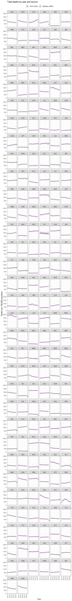

# 4 LINEAR MODEL

The first option to predicting excess mortality is to build a log-linear model that can be applied according to a [Generalized linear models (GLMs)](https://repository.rothamsted.ac.uk/download/25425465aa52d05e1a9e553b2daddeeffe15d0ba40f5f9b8937aaab5c3d29e1d/4410096/Nelder%201972.pdf) framework. A GLM has the structure

$$g\big(\mu_i\big) = \boldsymbol{x}_i \boldsymbol{\beta}$$

where $\mu_i$ is the expectation of response variable $Y_i$ such that $\mu_i \equiv \mathbb{E}\big(Y_i\big)$, $g$ is a link function, $\boldsymbol{x}_i$ is the $i$th row of the covariate matrix $\boldsymbol{X}$, and $\boldsymbol{\beta}$ is a vector of unknown coefficients. Akin to linear models, GLMs center around a linear predictor, $\boldsymbol{X}\boldsymbol{\beta}$, and allow for link functions other than the identity function. GLMs also allow for any distribution from the exponential family to model the dependent variable instead of just assuming it Gaussian. We predict the log of the ratio

$$\mu_i = log(s) = log\left(\frac{Observed}{Expected + covid19}\right) = \boldsymbol{x}_i \boldsymbol{\beta}$$
for $x_i \in \{SDI, NCD, COVID\}$ where $COVID$ represents the reported COVID mortality rate, $NCD$ are the NCD deaths rates as described in data input as well as the interaction of the SDI and COVID. The code used to predict the scaling factor as well as the estimation of the uncertainty is provided below. Results are in a tab to follow.

```r
#####################################################################################################################################
# Linear regression model using GLM instead of LM incase we change assumption about family
#####################################################################################################################################
rm(list = ls())
setwd(dirname(rstudioapi::getActiveDocumentContext()$path))

#####################################################################################################################################
# Load packages for all statistical analyses
pacman::p_load(highcharter, data.table, tidyr, dplyr, INLA, xgboost, mlr, countrycode)

# Can load the main data file again
load("Data/analysis_mod.Rda")

#####################################################################################################################################
# Aggregating from quarters to the sum for the entire year

df.lin      <- analysis_mod %>%
  dplyr::select(Country, iso3, WHO_region, cov_deaths, expected, observed, Nx, ncdr, sdi) %>%
  group_by(Country, iso3, WHO_region, Nx, ncdr, sdi) %>%
  summarize(covid = sum(cov_deaths), expected = sum(expected),
            observed = sum(observed), .groups = "drop") %>%
  ungroup() %>%
  mutate(excess = observed - expected, expectedc = expected + covid,
         ratio = observed/expectedc, covidr = covid/Nx, covsdi = covidr * sdi) %>%
  arrange(iso3)

#####################################################################################################################################
# Indices to identify rows

df.lin      <- df.lin %>% mutate(row = 1:nrow(df.lin))
ind.obsl    <- df.lin %>% filter(!is.na(excess)) %>% pull(row)

#####################################################################################################################################
# Approach
# 1) Run basic linear regression model
# 2) Sample 200 sets of coefficients using distribution given by inverse of variance matrix
# 3) Generate 200 realizations of fitted scaling factors for each country
# 4) Replace scaling factor with observed for places with data
# 5) Apply scaling factors to observed covid + expected to get predicted actual
# 6) Excess is predicted actual - expected
# 7) Use samples to summarise information by country but also for regional summaries

reg.mod     <- glm(log(ratio) ~ . - 1, data = df.lin %>% dplyr::select(ratio, sdi, covidr, covsdi, ncdr))
pe          <- reg.mod$coefficients  # point estimates
vc          <- vcov(reg.mod)         # variance-covariance

set.seed(1234)
draws       <- 200

# Distribution of coefficients
simbetas    <- MASS::mvrnorm(draws, pe, vc)

# Input data to scale the coefficients
df.lin.res  <- df.lin %>% dplyr::select(dimnames(simbetas)[[2]]) %>% as.matrix()

# Distribution of fitted values (these are scaling factors from the ratio of observed to covid plus expected)
replic      <- exp(df.lin.res %*% t(simbetas))

# Use the scaling factors to obtain distribution of excess deaths
fitdist1e   <- replic*replicate(draws, df.lin$expectedc) - replicate(draws, df.lin$expected)
obsvals     <- df.lin$excess # vector of observed values

# For the non-missing, replace predictions with the actual observed
for (i in 1:draws){
  fitdist1e[ind.obsl,] <- obsvals[ind.obsl]
}
```

The syntax used to generate country, regional and global uncertainty bounds can be shown through the link below.

```r
#####################################################################################################################################
# Basic functions to summarise 80% bootstrap intervals or sample from gaussian
#####################################################################################################################################

getsum <- function(x){
  tibble(mean = mean(x, na.rm = T),
         lwr  = quantile(x, 0.1, na.rm = T),
         uppr = quantile(x, 0.9, na.rm = T)) %>% round()
}

getsum2 <- function(x){
  c(mean(x, na.rm = T), quantile(x, 0.1, na.rm = T), quantile(x, 0.9, na.rm = T))
}

get.sample <- function(x){
  rnorm(draws, x[1], x[2])
}
#####################################################################################################################################
# Table of summarized values joined to observed and explanator data
df.lin.out   <- data.table::data.table(t(apply(fitdist1e, 1, getsum2))) %>%
  rename(y = "V1", low = "10%", high = "90%") %>%
  cbind(df.lin)  %>%
  mutate(y    = ifelse(!is.na(excess), excess, y),
         low  = ifelse(!is.na(excess), NA, low),
         high = ifelse(!is.na(excess), NA, high),
         source = ifelse(is.na(excess), "Predicted", "Observed")) %>% arrange(-y) %>%
  data.frame()

#####################################################################################################################################
# Indices by region

afro.indl   <- df.lin %>% filter(WHO_region == "AFRO") %>% pull(row)
emro.indl   <- df.lin %>% filter(WHO_region == "EMRO") %>% pull(row)
euro.indl   <- df.lin %>% filter(WHO_region == "EURO") %>% pull(row)
paho.indl   <- df.lin %>% filter(WHO_region == "AMRO") %>% pull(row)
searo.indl  <- df.lin %>% filter(WHO_region == "SEARO") %>% pull(row)
wpro.indl   <- df.lin %>% filter(WHO_region == "WPRO") %>% pull(row)
glob.indl   <- df.lin %>% pull(row)
#####################################################################################################################################

afro.sum   <- getsum(apply(fitdist1e[afro.indl,], 2, sum)) %>%
  mutate(region = "AFRO", covid = sum(df.lin[afro.indl,]$covid), Nx = sum(df.lin[afro.indl,]$Nx))
emro.sum   <- getsum(apply(fitdist1e[emro.indl,], 2, sum)) %>%
  mutate(region = "EMRO", covid = sum(df.lin[emro.indl,]$covid), Nx = sum(df.lin[emro.indl,]$Nx))
euro.sum   <- getsum(apply(fitdist1e[euro.indl,], 2, sum)) %>%
  mutate(region = "EURO", covid = sum(df.lin[euro.indl,]$covid), Nx = sum(df.lin[euro.indl,]$Nx))
paho.sum   <- getsum(apply(fitdist1e[paho.indl,], 2, sum)) %>%
  mutate(region = "PAHO", covid = sum(df.lin[paho.indl,]$covid), Nx = sum(df.lin[paho.indl,]$Nx))
searo.sum  <- getsum(apply(fitdist1e[searo.indl,], 2, sum)) %>%
  mutate(region = "SEARO", covid = sum(df.lin[searo.indl,]$covid), Nx = sum(df.lin[searo.indl,]$Nx))
wpro.sum  <- getsum(apply(fitdist1e[wpro.indl,], 2, sum)) %>%
  mutate(region = "WPRO", covid = sum(df.lin[wpro.indl,]$covid), Nx = sum(df.lin[wpro.indl,]$Nx))
global.sum <- getsum(apply(fitdist1e[glob.indl,], 2, sum)) %>%
  mutate(region = "Global", covid = sum(df.lin[glob.indl,]$covid), Nx = sum(df.lin[glob.indl,]$Nx))
#####################################################################################################################################

sum.exc.df <- rbind(afro.sum, emro.sum, euro.sum,
                    paho.sum, searo.sum, wpro.sum, global.sum) %>%
  rename(low = lwr, high = uppr) %>%
  mutate(excess = round(mean - covid),
         mean = round(mean), low = round(low), high = round(high),
         region = factor(region, levels = c("AFRO", "EMRO", "EURO", "PAHO", "SEARO", "WPRO", "Global")),
         model = "Basic Linear") %>%
  dplyr::select(model, region, Nx, covid, excess, low, mean, high)
```

# 5 MIXED EFFECTS MODEL

A second option is to assume a linear mixed effects model to predict the excess mortality rate. In a linear mixed effects model we let $y_j = (y_{j1}; \ldots ; y_{jn})$ denote the vector of repeated measurements for a group $j$. We reconsider the general model
$$y_j = X_j\beta + Zjbj + \varepsilon_j$$
in which $\beta$ is a vector of population-average regression coefficients called fixed effects, and where $b_j$ is a vector of group-specific regression coefficients. The $b_j$ describe how the evolution of the $j$th group deviates from the average. The matrices $X_j$ and $Z_j$ are matrices of known covariates. The residual components $\varepsilon_j$ are assumed to be independent $N(0, \Sigma_j)$, where $\Sigma_j$ depends on $j$.

In this case the variable of interest is the excess mortality rate i.e., the difference between the observed and expected relative to the overall population per 100,000. As shown in the data input tab, the data are disaggregated by quarter of deaths. For fixed effects we can take the overall covid death rates for the year, the expected death rates, the sdi and quarter specific covid, NCD and communicable disease death rates as well as the quarter. Random effects assumed for the region and income group. The model, is shown in the code below with results to follow in the final tab.

```r
#####################################################################################################################################
# Mixed effects model in INLA, similar syntax to GLM
#####################################################################################################################################

df.mixed  <- inla(excessr ~ cd_all + expectedr + sdi * covidr + ncdr + cmr + quarter - 1 +
                  f(WHO_region, model = "iid") + f(group, model = "iid"),
                  data = analysis_mod,
                  control.predictor= list(compute=TRUE))

pred.in   <- cbind(df.mixed$summary.fitted.values$mean, df.mixed$summary.fitted.values$sd)
fit.dist3 <- t(apply(pred.in, 1, get.sample)) # Assume distribution of fit is Normal with mean and sd

ind.obs <- analysis_mod %>% filter(!is.na(excess)) %>% pull(row) # indices for no data

#####################################################################################################################################
# For the observed replace predictions with actual excess rate estimates

for (i in 1:draws){
  fit.dist3[ind.obs,] <- analysis_mod$excessr[ind.obs]
}

fit.dist3e   <- analysis_mod$Nx     * fit.dist3

#####################################################################################################################################
# Results are by quarter, need to derive draws by country and then use those to derive draws by region etc
fit.dist3ef1 <- array(dim = c(194, draws))
for (j in 1:194){
  fit.dist3ef1[j,] <- apply(fit.dist3e[(j*4 - 3):(j*4),], 2, sum)
}

#####################################################################################################################################
# Summarize with bootstrap confidence intervals based on the distribution of the draws
df.mixed.out   <- data.table::data.table(t(apply(fit.dist3ef1, 1, getsum2))) %>%
  rename(y = "V1", low = "10%", high = "90%") %>%
  cbind(df.lin) %>% filter(!is.na(y))  %>%
  mutate(y    = ifelse(!is.na(excess), excess, y),
         low  = ifelse(!is.na(excess), NA, low),
         high = ifelse(!is.na(excess), NA, high),
         source = ifelse(is.na(excess), "Predicted", "Observed")) %>% arrange(-y)
```

The code for aggregating outputs to generate region specific uncertainty can be shown using the link below.

```r
#####################################################################################################################################
# Identify the rows for each region to aggregate the matrices accordingly

afro.ind    <- analysis_mod %>% filter(WHO_region == "AFRO") %>% pull(row)
emro.ind    <- analysis_mod %>% filter(WHO_region == "EMRO") %>% pull(row)
euro.ind    <- analysis_mod %>% filter(WHO_region == "EURO") %>% pull(row)
paho.ind    <- analysis_mod %>% filter(WHO_region == "AMRO") %>% pull(row)
searo.ind   <- analysis_mod %>% filter(WHO_region == "SEARO") %>% pull(row)
wpro.ind    <- analysis_mod %>% filter(WHO_region == "WPRO") %>% pull(row)
glob.ind    <- analysis_mod %>% pull(row)

#####################################################################################################################################
# Summarise within each aggregate, first by column (draw) and then across draws by aggregate

afro.sum.exc   <- getsum(apply(fit.dist3e[afro.ind,], 2, sum)) %>%
  mutate(region = "AFRO", covid = sum(analysis_mod[afro.ind,]$cov_deaths), Nx = .25*sum(analysis_mod[afro.ind,]$Nx))
emro.sum.exc   <- getsum(apply(fit.dist3e[emro.ind,], 2, sum)) %>%
  mutate(region = "EMRO", covid = sum(analysis_mod[emro.ind,]$cov_deaths), Nx = .25*sum(analysis_mod[emro.ind,]$Nx))
euro.sum.exc   <- getsum(apply(fit.dist3e[euro.ind,], 2, sum)) %>%
  mutate(region = "EURO", covid = sum(analysis_mod[euro.ind,]$cov_deaths), Nx = .25*sum(analysis_mod[euro.ind,]$Nx))
paho.sum.exc   <- getsum(apply(fit.dist3e[paho.ind,], 2, sum)) %>%
  mutate(region = "PAHO", covid = sum(analysis_mod[paho.ind,]$cov_deaths), Nx = .25*sum(analysis_mod[paho.ind,]$Nx))
searo.sum.exc  <- getsum(apply(fit.dist3e[searo.ind,], 2, sum)) %>%
  mutate(region = "SEARO", covid = sum(analysis_mod[searo.ind,]$cov_deaths), Nx = .25*sum(analysis_mod[searo.ind,]$Nx))
wpro.sum.exc  <- getsum(apply(fit.dist3e[wpro.ind,], 2, sum)) %>%
  mutate(region = "WPRO", covid = sum(analysis_mod[wpro.ind,]$cov_deaths), Nx = .25*sum(analysis_mod[wpro.ind,]$Nx))
global.sum.exc <- getsum(apply(fit.dist3e[glob.ind,], 2, sum)) %>%
  mutate(region = "Global", covid = sum(analysis_mod[glob.ind,]$cov_deaths), Nx = .25*sum(analysis_mod[glob.ind,]$Nx))

#####################################################################################################################################
sum.exc.exc <- rbind(afro.sum.exc, emro.sum.exc, euro.sum.exc,
                     paho.sum.exc, searo.sum.exc, wpro.sum.exc, global.sum.exc) %>%
  rename(low = lwr, high = uppr) %>%
  mutate(excess = round(mean - covid),
         mean = round(mean), low = round(low), high = round(high),
         region = factor(region, levels = c("AFRO", "EMRO", "EURO", "PAHO", "SEARO", "WPRO", "Global")),
         model = "Mixed Effects") %>%
  dplyr::select(model, region, Nx, covid, excess, low, mean, high)
```

# 6 GRADIENT BOOSTING

Machine learning applications involve articificial intelligence (AI) optimizations of the functions and corresponding parameters that summarise relationships characterising data. The process of AI learning consists of improving these functions and parameters using the data to train the functions. Machine learning does not explain everything but can be very useful in detecting patterns, even unknown and unidentifiable ones, as well as hidden correlations. This is very useful for a problem such as this in which the determinants and the extent of levels of excess mortality for the majority of countries are still largely unknown and even a crude estimate would be informative. We assume a supervised learning framework. In the supervised learning methods, the goal is to establish the relations between a range of predictors and a determined target. Specifically, we apply Gradient Boosting models. [Gradient boosting](https://en.wikipedia.org/wiki/Gradient_boosting) is one of the most powerful learning ideas introduced in the last twenty years. It is a machine learning technique for regression and classification problems which produces a prediction model in the form of an ensemble of weak prediction models, building the final model in an iterative fashion.

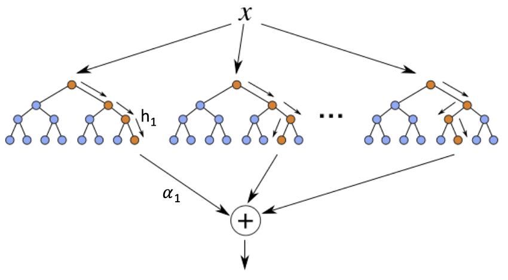

The purpose of boosting is to sequentially apply the weak classification algorithm to repeatedly modified versions of the data, thereby producing a sequence of weak classifiers $G_m(x)$, $m = 1, 2, ... , M$ that together reduce the error in the prediction.

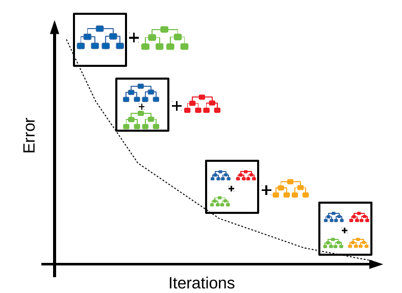

The final model finds the correct mathematical manipulations to turn the input into the output.

Again we use the model to estimate the scaling factor. We can also apply it to estimate the predicted excess which may be more robust. This is not shown yet. Syntax for obtaining the data structure and fitting the model are shown below.

```r
#####################################################################################################################################
# Machine learning model
#####################################################################################################################################

# Need to restructure the data to have the categorical variables and dummy variables

df.ml          <- analysis_mod

wreg           <- fastDummies::dummy_cols(as.numeric(df.ml$class))
wreg$.data     <- NULL
colnames(wreg) <- paste0("class", c(0, 1, 10, 20, 40, 70))

whog           <- fastDummies::dummy_cols(as.numeric(df.ml$WHO_region))
whog$.data     <- NULL
colnames(whog) <- paste0("WHO_region",c("AFRO","AMRO","EMRO","EURO","SEARO","WPRO"))

qg             <- fastDummies::dummy_cols(as.numeric(df.ml$quarter))
qg$.data       <- NULL
colnames(qg)   <- paste0("quarter",c("q1", "q2", "q3", "q4"))

ig             <- fastDummies::dummy_cols(as.numeric(df.ml$group))
ig$.data       <- NULL
colnames(ig)   <- paste0("group", c("LMIC","UMIC","HIC"))

#####################################################################################################################################
# Full dataset of wide array of variables to plug into the unsupervised learner

df.ml          <- df.ml %>%
  cbind(wreg) %>% cbind(whog) %>% cbind(qg) %>% cbind(ig) %>%
  dplyr::select(Country, iso3, index, observed, excess, excessr, pop,
         zratio, ratio, sdrat, mrat,
         expected, expectedr,
         sdi, ncdr, cmr, Nx, Stringency, Government, Containment, Economic,
         cov_deaths, covidr, casesr, cfr,
         expcov, covsdi, ncdsdi, cmr, cc_all, cd_all, row,
         paste0("class", c(0, 1, 10, 20, 40, 70)),
         paste0("WHO_region",c("AFRO","AMRO","EMRO","EURO","SEARO","WPRO")),
         paste0("quarter",c("q1", "q2", "q3", "q4")),
         paste0("group", c("LMIC","UMIC","HIC")))

#####################################################################################################################################
# Only looking the standardised log ratio

df.ml.ratio <- df.ml %>% dplyr::select(-c(excess, excessr, observed))

#####################################################################################################################################
# Rescale/Normalize all the predictors to the zero-one scale based on the max and min

nc <- ncol(df.ml.ratio)
maxs    <- apply(df.ml.ratio[,c(9:nc)], 2, max, na.rm=T)
mins    <- apply(df.ml.ratio[,c(9:nc)], 2, min, na.rm=T)
scaled  <- cbind(df.ml.ratio[,c(1:8)], scale(df.ml.ratio[,c(9:nc)], center=mins, scale = maxs-mins))

#####################################################################################################################################
# Training dataset with all observed
# Test dataset with all 194 countries and 4 quarters

train_  <- scaled %>% filter(index==1) %>% dplyr::select(-c(Country, ratio, index, iso3, pop, sdrat, mrat))
test_   <- scaled %>% dplyr::select(-c(Country, ratio, index, iso3, pop, sdrat, mrat))

#####################################################################################################################################
# Dummy matrix, placeholder for results
fit.dist <- array(dim = c(nrow(test_), draws))

set.seed(1234)
seeds <- runif(draws, 10, 100000)

#####################################################################################################################################
for (i in 1:ncol(fit.dist)){
  print(paste(i))
  set.seed(seeds[i])

  # Using MLR package, set-up machline learning task task
  trainTaskFit <- makeRegrTask(data = train_, target = "zratio", id = paste0("fit",i))
  testTaskFit  <- makeRegrTask(data = test_ %>% mutate(zratio = 0), target = "zratio", id = paste0("fitp",i))

  # Objective is to minimize the error
  xgb_learner  <- makeLearner(
    "regr.xgboost",
    par.vals = list(objective = "reg:squarederror", eval_metric = "rmse")
  )

  # Will perform a tuning of the parameters as a part of the estimation
  xgb_params   <- makeParamSet(
    makeIntegerParam("nrounds", lower = 100, upper = 500),
    makeIntegerParam("max_depth", lower = 3, upper = 10),
    makeNumericParam("min_child_weight",lower = 1,upper = 10),
    makeNumericParam("eta", lower = .1, upper = .7),
    makeNumericParam("lambda", lower = -1, upper = 0, trafo = function(x) 10^x),
    makeNumericParam("subsample",lower = 0.5,upper = 1),
    makeNumericParam("colsample_bytree",lower = 0.5,upper = 1)
  )

  control      <- makeTuneControlRandom(maxit = 1)
  resample_desc<- makeResampleDesc("CV", iters = 5) # 5-fold cross validation

  # name list of the tuned parameters
  tuned_params <- tuneParams(
    learner    = xgb_learner,
    task       = trainTaskFit,
    resampling = resample_desc,
    par.set    = xgb_params,
    control    = control
  )

  # for the hyper-parameters
  xgb_tuned_learner <- setHyperPars(
    learner    = xgb_learner,
    par.vals   = tuned_params$x
  )

  fit.mod      <- train(xgb_tuned_learner, trainTaskFit) # training including tuning and validation
  pred.fit     <- predict(fit.mod, testTaskFit)          # prediction using final model
  fit.dist[,i] <- pred.fit$data %>% pull(response)       # pull vector of predictions
}
#####################################################################################################################################

fit.dist2 <-  exp(as.matrix(df.ml$mrat + df.ml$sdrat*fit.dist)) # rescale result to log-scale then exponentiate
ind.obs   <- analysis_mod %>% filter(!is.na(excess)) %>% pull(row) # indices of observed

#####################################################################################################################################
# For the observed values, replace predictions with observed,
# predictions only necessary for the unknown

for (i in 1:draws){
  fit.dist2[ind.obs,] <- analysis_mod$ratio[ind.obs]
}

#####################################################################################################################################
# Use predicted scaling factors to scale up the sum of the expected and covid to estimate actual
fit.dist2e   <- analysis_mod$expcov * fit.dist2 - analysis_mod$expected

#####################################################################################################################################
# Also need country-year specific instead of just year
fit.dist2ef1 <- array(dim = c(194, draws))
for (j in 1:194){
  fit.dist2ef1[j,] <- apply(fit.dist2e[(j*4 - 3):(j*4),], 2, sum)
}

df.ml.out   <- data.table::data.table(t(apply(fit.dist2ef1, 1, getsum2))) %>%
  rename(y = "V1", low = "10%", high = "90%") %>%
  cbind(df.lin) %>% filter(!is.na(y))  %>% # mutate(y = y/Nx, low = low/Nx, high = high/Nx) %>%
  mutate(y    = ifelse(!is.na(excess), excess, y),
         low  = ifelse(!is.na(excess), NA, low),
         high = ifelse(!is.na(excess), NA, high),
         source = ifelse(is.na(excess), "Predicted", "Observed")) %>% arrange(-y)
```

The code for aggregating outputs to generate region specific uncertainty can be shown using the link below.

```r
#####################################################################################################################################
# Similar to above, indices by region for aggregation
afro.ind    <- analysis_mod %>% filter(WHO_region == "AFRO") %>% pull(row)
emro.ind    <- analysis_mod %>% filter(WHO_region == "EMRO") %>% pull(row)
euro.ind    <- analysis_mod %>% filter(WHO_region == "EURO") %>% pull(row)
paho.ind    <- analysis_mod %>% filter(WHO_region == "AMRO") %>% pull(row)
searo.ind   <- analysis_mod %>% filter(WHO_region == "SEARO") %>% pull(row)
wpro.ind    <- analysis_mod %>% filter(WHO_region == "WPRO") %>% pull(row)
glob.ind    <- analysis_mod %>% pull(row)

#####################################################################################################################################
afro.sum.rat   <- getsum(apply(fit.dist2e[afro.ind,], 2, sum)) %>%
  mutate(region = "AFRO", covid = sum(analysis_mod[afro.ind,]$cov_deaths), Nx = .25*sum(analysis_mod[afro.ind,]$Nx))
emro.sum.rat   <- getsum(apply(fit.dist2e[emro.ind,], 2, sum)) %>%
  mutate(region = "EMRO", covid = sum(analysis_mod[emro.ind,]$cov_deaths), Nx = .25*sum(analysis_mod[emro.ind,]$Nx))
euro.sum.rat   <- getsum(apply(fit.dist2e[euro.ind,], 2, sum)) %>%
  mutate(region = "EURO", covid = sum(analysis_mod[euro.ind,]$cov_deaths), Nx = .25*sum(analysis_mod[euro.ind,]$Nx))
paho.sum.rat   <- getsum(apply(fit.dist2e[paho.ind,], 2, sum)) %>%
  mutate(region = "PAHO", covid = sum(analysis_mod[paho.ind,]$cov_deaths), Nx = .25*sum(analysis_mod[paho.ind,]$Nx))
searo.sum.rat  <- getsum(apply(fit.dist2e[searo.ind,], 2, sum)) %>%
  mutate(region = "SEARO", covid = sum(analysis_mod[searo.ind,]$cov_deaths), Nx = .25*sum(analysis_mod[searo.ind,]$Nx))
wpro.sum.rat  <- getsum(apply(fit.dist2e[wpro.ind,], 2, sum)) %>%
  mutate(region = "WPRO", covid = sum(analysis_mod[wpro.ind,]$cov_deaths), Nx = .25*sum(analysis_mod[wpro.ind,]$Nx))
global.sum.rat <- getsum(apply(fit.dist2e[glob.ind,], 2, sum)) %>%
  mutate(region = "Global", covid = sum(analysis_mod[glob.ind,]$cov_deaths), Nx = .25*sum(analysis_mod[glob.ind,]$Nx))

#####################################################################################################################################
sum.exc.rat <- rbind(afro.sum.rat, emro.sum.rat, euro.sum.rat,
                     paho.sum.rat, searo.sum.rat, wpro.sum.rat, global.sum.rat) %>%
  rename(low = lwr, high = uppr) %>%
  mutate(excess = round(mean - covid),
         mean = round(mean), low = round(low), high = round(high),
         region = factor(region, levels = c("AFRO", "EMRO", "EURO", "PAHO", "SEARO", "WPRO", "Global")),
         model = "Gradient Boosting") %>%
  dplyr::select(model, region, Nx, covid, excess, low, mean, high)
```

# 7 POISSON MODELS

## *C19 Excess Mortality Model*

### *Jon Wakefield, William Msemburi, Serge Aleshin-Guendel, Xihong Lin*

### *April 29, 2021*

## 7.1 A Generative Model for Excess Deaths

For country $c$, let:

- $N_c$ be the population size.
- $Y_c$ be the total deaths in 2020 (observed and assumed to be complete with good coverage).
- $E_c$ be (modeled) expected deaths in 2020, in the absence of C19. William’s model assumes a RW2, which is a reasonable choice.
- $R_c$ be reported C19 deaths in 2020 (observed). This seems to be referred to as *direct* impact (confirmed C19).
- $U_c$ be unreported C19 deaths in 2020 (unobserved). This seems to be referred to as *indirect* impact.
- $T_c$ be total C19 deaths, so $T_c=R_c+U_c$.
- $W_c$ be difference between the total deaths and the sum of the expected and the true C19 deaths. Hence,

$$\begin{equation}
Y_c =
E_c+T_c + W_c = E_c + R_c+U_c +W_c.
\tag{7.1}
\end{equation}$$

- In an ideal world we want to estimate $U_c$ and $W_c$
- $W_c$ could be negative, which makes modeling a bit trickier.

Hypothetical model. From (7.1) and assuming $W_c=0$:

$$\begin{eqnarray}
Y_c | m_c^t &\sim& \mbox{Poisson}(E_c + N_c m_c^t)
\tag{7.2}
\end{eqnarray}$$

and

$$\begin{eqnarray}
T_c | m_c^t &\sim& \mbox{Poisson}(N_c m_c^t) \tag{7.3}\\
R_c | T_c ,p_c^r &\sim& \mbox{Binomial}(T_c , p_c^r) \\
R_c | m_c^t , p_c^r &\sim& \mbox{Poisson}(N_c m_c^t p_c^r) \tag{7.4}
\end{eqnarray}$$
where

- $m_c^t$ is the C19 death rate.
- $p_c^r$ is the reporting rate for C19, i.e.,~given a death from C19, what’s the probability it is reported as C19?

We have
$$T_c = R_c + U_c,\qquad U_c \sim \mbox{Poisson}(N_c m_c^t [1-p_c^r]) .$$

We can estimate $p_c^r$ from the models in equations (7.2) and (7.4); we have two main unknowns, the rate of true C19 deaths, $m_c^t$, and the reporting probability $p_c^r$. In practice replace Poissons by overdispersed versions.

We could specify models for $m^t$ and $p^t$. For example, a log-linear model for $m_c^t$ and a logistic regression model for $p_c^r$:
$$\begin{eqnarray}
\log m_c^t &=& \mathbf{x}_c^t \mathbf{\beta}^t + \epsilon_c^t \tag{7.5}\\
\mbox{logit } p_c^r &=& \mathbf{x}_c^r \mathbf{\beta}^r + \epsilon_c^r \tag{7.6}
\end{eqnarray}$$

where $\epsilon_c^t \sim_{iid} \mbox{N}(0,\sigma^2_t)$ and $\epsilon_c^r \sim_{iid} \mbox{N}(0,\sigma^2_r)$ and $\epsilon_c^t$ and $\epsilon_c^r$ are independent and allow for overdispersion. We could also include spatial random effects. We could also allow for uncertainty in $E_c$, if we felt this important.

As an alternative to the Poisson with IID random effects, we can specify:
$$\begin{eqnarray}
Y_c | m_c^t&\sim& \mbox{NegBin}(E_c + N_cm_c^t ,\phi^y ) \tag{7.7}\\
R_c | m_c^t , p_c^r &\sim& \mbox{NegBin}(N_c m_c^t p_c^r,\phi^t) \tag{7.8}
\end{eqnarray}$$

where $\phi^y,\phi^t$ are overedispersion parameters.

**Report:** In the original concept note, it was stated that, “to assist WHO and UN Member States to obtain accurate estimates of numbers of deaths attributable to the direct and indirect impacts of the pandemic.”

So in terms of the above conceptual framework, we want both total C19 $T_c$ and the $W_c$ (if we can find a way to estimate this). And $U_c=T_c-R_c$ (indirect).

## 7.2 Working Models

An obvious model is,
$$\begin{eqnarray}
Y_c | m^N_c &\sim& \mbox{Poisson}(N_c m^N_c) \tag{7.9}\\
\log m^N_c& =& \mathbf{x}_c \mathbf{\beta} + \epsilon^N_c
\end{eqnarray}$$
where $\epsilon^N_c \sim_{iid} \mbox{N}(0,\sigma^2_\epsilon).$ Spatial terms could easily be added to the loglinear model.

I wonder whether it is more desirable to consider joint model (7.9) and model (7.8) by assuming the regression model for $m^N_c$ in (7.9) and the regression model (7.5) for $m_c^t$ and (7.6). This makes less assumptions by allowing total deaths smaller than expected deaths.

Also from David’s slides, in spring 2020, non-covid-related deaths were smaller than expected deaths but in winter 2020, non-covid-related deaths were higher than expected deaths. This suggests that we want to regression models for $m^N_c$ and $m_c^t$ depend on time.

After fitting these models, excess deaths are $N_c m^N_c-E_c$ and covid deaths are $N_c m_c^t$.

Naive total difference is
$$Y_c-E_c,$$
and
$$Y_c-E_c-R_c$$
is naive remainder (excess of excess), where we recognize that both of these could be negative. From our model we could use $N_c\widehat{m}_c^N -E_c$ as naive total difference, and $N_c\widehat{m}_c^N-E_c-R_c$ as excess of excess where $\widehat{m}_c^N$ is the fitted value based on covariates for countries with no total deaths. This doesn’t allow us to get at total C19 deaths, unlike the original model, given by (7.2) and (7.4).

Initially, we had, $Y_c = E_c + R_c+U_c+W_c$, which suggests an additive model may be useful. An alternative model is,
$$\begin{eqnarray}
Y_c | m_c^E , m_c^N& \sim &\mbox{Poisson}( [E_c + N_c m_c^N]\mbox{e}^{\epsilon_c} ) \tag{7.11}\\
\log m^N_c& =& \alpha^N+ \mathbf{x}_c \mathbf{\beta}^N \\
\log E_c &\sim_{iid} & \mbox{N}(\mu^E_{c},\sigma^{E 2}_c) \\
\epsilon_c &\sim_{iid}& \mbox{N}(0,\sigma_\epsilon^2)
\end{eqnarray}$$
where we have left off the spatial random effects. The RHS can go below $E_c$, for a small number of countries this happens (though probably they have good data anyway?). The $E_c$ term then is expected but allows to drop below, and the second term is modeling: covid deaths and other deaths dropping or falling due to the altered circumstances. It makes sense for those terms to depend on the population size $N_c$ (and will also allow flexibility later when we want to bring in age and sex).

## 7.3 Model Assessment}

## In-Sample

Consider the generic Poisson-Lognormal model,
$$Y_ c | \epsilon_c \sim \mbox{Poisson}( N_c \theta_c \mbox{e}^{\epsilon_c} ) ,\qquad \epsilon_c \sim \mbox{N}(0,\sigma_\epsilon^2).$$
Pearson residuals are:
$$r_c^P = \frac{y_c-\widehat{y}_c}{\sqrt{\widehat{y}_c}}$$

Table 7.1: Fitted values under different interpretations of $\epsilon_c$.

| Intrepretation | Fitted value $\widehat{y}_c$ |
| --- | --- |
| Measurement Error | $N_c \theta_c$ |
| Overdispersion | $N_c \theta_c \mbox{e}^{\sigma^2_\epsilon/2}$ |
| True Signal | $N_c \theta_c \mbox{e}^{\epsilon_c}$ |

## Out-of-Sample

Systematically leave out data from countries with ``full data". And then obtain predictive distributions for these countries based on the covariates.

We will first use leave-one-out (LOO) cross-validation Vehtari, Gelman, and Gabry (2017). This uses the *loo* package in *R*. For each left out point $c$ we calculate

$$\log \Pr( y_c | \mathbf{y}_{-c}),$$
i.e.,~the log of the predictive distribution obtained from all data with country $c$ left out, and evaluated at $y_c$. The predictive is the sampling model for the data (Poisson in our case), averaged over the posterior with country $c$ left out:

$$\Pr( y_c | \mathbf{y}_{-c}) = \int_\theta \Pr(y_c | \theta) \times p(\theta | \mathbf{y}_{-c}) ~d\theta.$$

An overall measure of the fit of a model is,
$$\sum_{c=1}^C \log \Pr( y_c | \mathbf{y}_{-c}).$$

Czado, Gneiting, and Held (2009) has examples of other metrics.

## References

Czado, Claudia, Tilmann Gneiting, and Leonhard Held. 2009. “Predictive Model Assessment for Count Data.” *Biometrics* 65 (4): 1254–61.

Riebler, Andrea, Sigrunn H Sørbye, Daniel Simpson, and Håvard Rue. 2016. “An Intuitive Bayesian Spatial Model for Disease Mapping That Accounts for Scaling.” *Statistical Methods in Medical Research* 25 (4): 1145–65.

Vehtari, Aki, Andrew Gelman, and Jonah Gabry. 2017. “Practical Bayesian Model Evaluation Using Leave-One-Out Cross-Validation and Waic.” *Statistics and Computing* 27 (5): 1413–32.

### Appendix: Simple analysis with no covariates

From (7.2) we obtain

$$\widehat{m}_c^t = \frac{Y_c-E_c}{N_c},$$
and from (7.4),

$$\widehat{p}_c^r = \frac{R_c}{N_c} \times \frac{1}{\widehat{m}_c^t},$$
which simplifies to

$$\widehat{p}_c^{r}= \frac{R_c}{Y_c-E_c}.$$
This gives

$$\widehat{T}_c = \frac{R_c}{\widehat{p}_c^r } = Y_c-E_c,$$

as we might expect. This naive estimator can be improved upon, and including covariates via (7.6) will also allow smoothing.

If we allow uncertainty on $E_c$ then it allows the covariate and spatial models to have more influence (since $Y_c-E_c$ is not fixed).

### Appendix: C19 Adjusted Difference Model

If $W_c=0$ then
$$\begin{eqnarray*}
Y_c-R_c = E_c + U_c &\sim& \mbox{Poisson}(E_c + N_c m^u_c)\\
\log m^u_c& =& \mathbf{x}_c \mathbf{\beta}+ \epsilon^u_c + S^u_c
\end{eqnarray*}$$
and then $T_c =R_c+U_c$ where $U_c \sim \mbox{Poisson}(N_c m^u_c)$ and indirect is $U_c$ only.\

Alternatively, suppose $W_c \neq 0$. The problem here is that $\mbox{E}[W_c] =N_cm_c^w$ may be negative so I don’t think going this route makes much sense. If we think $m_c^w \ll m_c^u$ then does it make sense to consider $m^\text{sum}_c = m_c^w + m_c^u$:
$$\begin{eqnarray*}
Y_c-R_c = E_c + U_c + W_c &\sim& \mbox{Poisson}(E_c + N_c m^\text{sum}_c)\\
\log m^\text{sum}_c& =& \mathbf{x}_c \mathbf{\beta} + \epsilon^\text{sum}_c + S^\text{sum}_c
\end{eqnarray*}$$
This is not a generative model. Output: $N_c\widehat{m}^\text{sum}_c-E_c$ is remainder (excess of excess, that is, sum of direct and indirect), where we recognize that this could be negative for some countries. NEED TO THINK MORE.

### Appendix: WHO Original Model

Model the ratio,
$$Z_c = \log \left(\frac{Y_c}{E_c+R_c}
\right) = \mathbf{x}_c \mathbf{\beta}.$$
Note:
$$Z_c = \log \left(\frac{Y_c}{E_c+R_c}
\right) = \log \left(\frac{Y_c/N_c}{(E_c+R_c)/N_c}
\right)$$
and one of the covariates is $R_c/N_c$.

From (7.1) we have $E_c+R_c \approx Y_c-U_c$ so
$$Z_c \approx \log \left(\frac{Y_c}{Y_c-U_c}
\right) = \log \left(\frac{1}{1-U_c/Y_c}
\right)$$
so the transformed version of the proportion of unreported C19 cases to total deaths.

Very approximately, for the ratio $r$,
$$r_c = \mbox{E}[e^{Z_c}] = \mbox{E}\left[ \frac{Y_c}{E_c+R_c} \right] \approx \frac{\mbox{E}[Y_c]}{E_c+\mbox{E}[R_c]}
=\frac{E_c + N_cm_c^t}{E_c+N_cm_c^t p_c^r }$$
The total excess deaths $T$ is estimated as
$$\widehat{T}_c = \widehat{r_c} \times (E_c+R_c) - E_c.$$

**Simple analysis with no covariates:** $\mbox{E}[Z_c] = \alpha_c$, and
$$\widehat{\alpha}_c = \log \left(
\frac{Y_c}{E_c+R_c}
\right)$$

and

$$\widehat{T}_c =\frac{Y_c}{E_c+R_c} \times (E_c+R_c) - E_c = Y_c-E_c.$$

### Appendix: Gradient Boosting Trees

# 8 RESULTS

## 8.1 Regional comparisons across models

[interactive chart not shown]

## 8.2 Regional comparisons for each model

### 8.2.1 LINEAR MODEL

#### 8.2.1.1 Option 1 country excess

[interactive chart not shown]

#### 8.2.1.2 Option 1 regional and global

Overall for the year 2020:

- Global: 1.81 million COVID-19 and 3.31 million estimated excess deaths (UI 2.73-3.91)
  - AFRO: 43 thousand COVID-19 and 101 thousand estimated excess deaths (UI 7-213)
  - EMRO: 120 thousand COVID-19 and 288 thousand estimated excess deaths (UI 236-340)
  - EURO: 586 thousand COVID-19 and 1.13 million estimated excess deaths (UI 1.12-1.14)
  - PAHO: 860 thousand COVID-19 and 1.32 million estimated excess deaths (UI 1.3-1.34)
  - SEARO: 184 thousand COVID-19 and 439 thousand estimated excess deaths (UI 233-661)
  - WPRO: 20 thousand COVID-19 and 13 thousand estimated excess deaths (UI -203-235)

#### 8.2.1.3 Barplots of option 1 regional excess deaths

[interactive chart not shown]

### 8.2.2 MIXED-EFFECTS MODEL

#### 8.2.2.1 Option 2 country excess

[interactive chart not shown]

#### 8.2.2.2 Option 2 regional and global

Overall for the year 2020:

- Global: 1.81 million COVID-19 and 3.86 million estimated excess deaths (UI 3.59-4.1)
  - AFRO: 43 thousand COVID-19 and 312 thousand estimated excess deaths (UI 248-376)
  - EMRO: 120 thousand COVID-19 and 426 thousand estimated excess deaths (UI 354-498)
  - EURO: 586 thousand COVID-19 and 1.12 million estimated excess deaths (UI 1.11-1.13)
  - PAHO: 860 thousand COVID-19 and 1.31 million estimated excess deaths (UI 1.3-1.32)
  - SEARO: 184 thousand COVID-19 and 624 thousand estimated excess deaths (UI 428-788)
  - WPRO: 20 thousand COVID-19 and 62 thousand estimated excess deaths (UI -71-207)

#### 8.2.2.3 Barplots of option 2 regional excess deaths

[interactive chart not shown]

### 8.2.3 GRADIENT BOOSTING MACHINE

#### 8.2.3.1 Option 3 country excess

[interactive chart not shown]

#### 8.2.3.2 Option 3 regional and global

Overall for the year 2020:

- Global: 1.81 million COVID-19 and 2.65 million estimated excess deaths (UI 1.15-4.1)
  - AFRO: 43 thousand COVID-19 and 392 thousand estimated excess deaths (UI -129-934)
  - EMRO: 120 thousand COVID-19 and 386 thousand estimated excess deaths (UI 209-567)
  - EURO: 586 thousand COVID-19 and 1.11 million estimated excess deaths (UI 1.08-1.15)
  - PAHO: 860 thousand COVID-19 and 1.31 million estimated excess deaths (UI 1.28-1.35)
  - SEARO: 184 thousand COVID-19 and 368 thousand estimated excess deaths (UI -345-1127)
  - WPRO: 20 thousand COVID-19 and -933 thousand estimated excess deaths (UI -1562–178)

#### 8.2.3.3 Barplots of option 3 regional excess deaths

[interactive chart not shown]

### 8.2.4 Comparison by model (regional and global)

| model | region | Nx | covid | excess.l | excess.m | excess.h |
| --- | --- | --- | --- | --- | --- | --- |
| Basic Linear | AFRO | 11201.61235 | 42600 | 6618 | 101132 | 212647 |
| Basic Linear | EMRO | 7257.20786 | 119815 | 235989 | 287790 | 340016 |
| Basic Linear | EURO | 9328.88131 | 586025 | 1117897 | 1128575 | 1139865 |
| Basic Linear | PAHO | 10181.21127 | 860248 | 1303105 | 1320314 | 1338440 |
| Basic Linear | SEARO | 20213.8663 | 183542 | 232848 | 438857 | 660752 |
| Basic Linear | WPRO | 19398.79337 | 19893 | -202831 | 13271 | 235066 |
| Basic Linear | Global | 77581.57246 | 1812123 | 2732262 | 3306910 | 3911948 |
| Gradient Boosting | AFRO | 11201.61235 | 42600 | -129132 | 392057 | 933858 |
| Gradient Boosting | EMRO | 7257.20786 | 119815 | 209088 | 385870 | 566628 |
| Gradient Boosting | EURO | 9328.88131 | 586025 | 1081086 | 1110835 | 1147734 |

[output cut: 11 more lines]